# McKenzie Reintroduction Notebook

```r
#packages here
require(tidyverse)
```

# Summary

Utilize current and emerging genetic methods to determine the effectiveness of trapping and transport of adult salmonids above and below Portland District hydro-electric projects in the Willamette River Basin to increase population abundance, productivity and diversity. This includes determining if returning spawners are progeny of previous transports and the lifetime fitness of transported individuals - from proposal

# Aims

**Goals from USACE Proposal**

1. Determine the number and proportion of unmarked adult Chinook salmon sampled at various locations in the South Fork McKenzie River (e.g. Cougar Trap and spawning grounds below Cougar dam) in 2016-2020 that can be assigned as progeny of Chinook salmon previously released above Cougar Dam, South Fork McKenzie River in 2011-2017.
2. Estimate the TLF for Chinook salmon reintroduced above Cougar Dam in 2011-2015. These estimates include unmarked adult offspring sampled at Cougar Dam, as well as unmarked spawners encountered on spawning grounds below the dam in 2014-2019.
3. Estimate the effects of release date and release site on the total lifetime fitness of adult spring Chinook salmon released above Cougar Dam in 2011-2015.
4. Estimate cohort replacement rate (CRR), or “the number of future spawners produced by a spawner” for spring Chinook salmon released above Cougar Dam in 2011-2015.
5. Estimate the effective number of breeders (Nb) for the adult salmon population reintroduced above Cougar Dam in 2011-2015.
6. Estimate and report the annual abundance and age structure of adult Chinook salmon that return to the South Fork McKenzie River that can be confidently assigned to parents through genetic pedigree in 2016-2020.
7. Evaluate fitness differences between HOR and NOR Chinook salmon released above Cougar Dam in 2011-2015 through assignment of adult offspring returns in 2014-2020.

**Additional Goals**  
In addition to goals designated in the USACE propasal these data can be used to address several questions outlined by previous workers on the project or me:

1. Estimate heritability of fitness traits (e.g. Evans et al 2019)
2. Estimate selection gradients for fitness traits (eg extend Evans et al 2019 analysis from selection on release date to include new trait data )
3. Is there a fitness difference between first generation natural origin fish (i.e. NOR with HORxHOR parents) and later generation NOR fish/fish with unknown ancestry?
4. Sythesize/compare these results with those from other reports years to identify trends.

# Methods Summary

from USACE proposal:

1. Tissue samples have been collected from unmarked adult spring Chinook salmon sampled at the Trap and transported above Cougar Dam in 2016 (N = 302), 2017 (N = 244), 2018 (N = 120), 2019 (N = 166) and 2020 (N ~ 225). In addition, a few marked fish were sampled at the Trap and transported above Cougar Dam in 2016 (N = 71), 2017 (N = 6) and 2019 (N = 8). Note, the 2016 and 2017 samples have already been genotyped. DNA will be extracted from fin clips collected in 2018-2020 (N ~ 511) using the method of Ivanova et al. (2006). Samples will be genotyped at 11 microsatellite markers and one sex identification marker. Tissue samples have also been collected from hatchery spring Chinook collected at the McKenzie Hatchery and outplanted above Cougar Dam in 2014 (N = 683), 2015 (N = 669), 2016 (N =518), 2017 (N = 546), 2018 (N = 541) and 2019 (N = 451). DNA will be extracted from fin clips collected in 2014-2017 (N = 2,416) using the method of Ivanova et al. (2006). Samples will be genotyped at 11 microsatellite markers and one sex identification marker.
2. Genetic-based parentage assignments will be made for all unmarked adult spring Chinook salmon sampled in the South Fork McKenzie River in 2016-2019 using genotypes from salmon previously released above Cougar Dam as potential parents in 2011-2016. Two analytical approaches will be used as implemented in the software programs: CERVUS (Kalinowski et al. 2007), and COLONY (Wang and Santure 2009).
3. General Linear Models (GLM) will be used to estimate the effect of alternate release strategies (i.e. site and date), when possible, on the total lifetime fitness of adult spring Chinook salmon transported above Cougar Dam in 2011-2015.
4. A Chi-square test will be used to compare the parentage assignment rate of adult Chinook salmon that enter the trap and haul facility prior to and after September 1st.
5. Cohort Replacement Rate (CRR) of Chinook salmon outplanted above Cougar Dam in 2011-2015 will be estimated as the mean number of adult Chinook salmon produced per adult spawner.
6. Single generation (Waples and Do 2008; Tallmon et al. 2008) and cross generation methods (Waples 1989, 2005; Frankham 1995) will be used to estimate the effective number of breeders of spring Chinook salmon transported above Cougar Dam in 2011-2015.
7. The abundance and age structure of assigned adult offspring returns will be determined through genetic parentage analyses.

# Previous Run - Inferring Methods

In this section we pore through methods sections, logs and output files to infer the methods used in the previous run in lead up to attempt attempt to recreate the previous analysis/results.

## Genotypes

**From Sard 2016 supplement:**

> We isolated total genomic DNA from tissue samples using a glass-fiber protocol developed by Ivanova et al. (2006) and amplified 11 highly polymorphic microsatellites using the polymerase chain reaction (PCR): Ots201, Ots208b, Ots209, Ots211, Ots212, Ots215, Ots249, Ots253, Ots311, Ots409, and Ots515 (Banks et al., 1999, Greig et al., 2003, Naish and Park, 2002, Williamson et al., 2002). Most reintroduced adults were genotyped at 10 or more loci (99%, n= 6,079/6,119). We also genotypically sexed all adults using the sex-linked marker Oty3 because it has been shown to accurately identify the sex of Chinook salmon in the Willamette River basin (Brunelli et al., 2008). We visualized PCR products on an ABI 3730XL DNA analyzer (Applied Biosystems, Inc., Foster City, CA) and size scored genotypes using GeneMapper software (Applied Biosystems, Inc.).

**From Banks June 2014 Report:**

> Total genomic DNA was isolated (Ivanova et al. 2006) from all adults, and a subset of juveniles each year. DNA samples were amplified at 11 highly polymorphic microsatellites using polymerase chain reaction (PCR): Ots201, Ots208b, Ots209, Ots211, Ots212, Ots215, Ots249, Ots253, Ots311, Ots409, and Ots515 (Banks et al. 1999; Greig et al. 2003; Naish and Park 2002; Williamson et al. 2002). Brunelli et al. (2008) found that the sex-linked marker Oty3 can correctly identify sex of Willamette River Chinook. Accordingly, we used this marker to determine the sex of adult Chinook and compared these results to those from phenotypic assessments. All PCR products were visualized on an ABI 3730XL DNA Analyzer (Applied Biosystems, Inc., Foster City, CA), and scored using GeneMapper software (Applied Biosystems, Inc., Foster City, CA).

## Parentage

### CERVUS

**Installing CERVUS** installed wine to run cervus on mac, run with command below

```bash
#start a console window in wine using the app shortcut
cd .wine/drive_c/Program\ Files\ \(x86\)/Field\ Genetics/Cervus
wine start Cervus.exe
```

**Identifying Data**

```r
#there are several genotype files throughout the data shared by nick named "adult_master" . which one is the actual master file
a <- read_tsv(file = "Sard_data/Genetic Pedigrees/Adults to Adults/Below Dam/Cervus/Genotypes/Input/04DEC13_cougar_adult_master.txt")

b <- read_tsv(file = "Sard_data/2015/14JUL2015_cougar_adult_master.txt")

c <- readxl::read_xlsx("previous_run_info/10APR2016_Cougar_adult_master.xlsx")

d <- read_tsv(file = "Sard_data/Genetic Pedigrees/Adults to Adults/Cervus/04DEC2015_Cougar_adult_master.txt")

e <- read_tsv(file = "Sard_data/Genetic Pedigrees/Adults to Adults/Cervus/Genotypes/04JAN2016_Cougar_adult_master.txt")


#how much overlap is there in samples between these files
length(intersect(a$Sample.Name, b$Sample.Name))
```

```
## [1] 5677
```

```r
length(intersect(b$Sample.Name, c$Sample.Name))
```

```
## [1] 6119
```

```r
length(intersect(a$Sample.Name, c$Sample.Name))
```

```
## [1] 5677
```

```r
#all but two samples (blank rows) in a are in b and c, and all of b is in c... lets looks more closely
a %>%
  group_by(year) %>%
  tally()
```

| year | n |
| --- | --- |
| 2007 | 746 |
| 2008 | 873 |
| 2009 | 1386 |
| 2010 | 748 |
| 2011 | 731 |
| 2012 | 948 |
| 2013 | 245 |
| NA | 2 |

```r
b %>%
  group_by(year) %>%
  tally()
```

| year | n |
| --- | --- |
| 2007 | 746 |
| 2008 | 873 |
| 2009 | 1386 |
| 2010 | 748 |
| 2011 | 731 |
| 2012 | 948 |
| 2013 | 687 |

```r
c %>%
  group_by(year) %>%
  tally()
```

| year | n |
| --- | --- |
| 2007 | 746 |
| 2008 | 873 |
| 2009 | 1386 |
| 2010 | 748 |
| 2011 | 731 |
| 2012 | 948 |
| 2013 | 687 |
| 2014 | 214 |
| 2015 | 260 |

```r
d %>%
  group_by(year) %>%
  tally()
```

| year | n |
| --- | --- |
| 2007 | 746 |
| 2008 | 873 |
| 2009 | 1386 |
| 2010 | 748 |
| 2011 | 731 |
| 2012 | 948 |
| 2013 | 687 |
| 2014 | 214 |

```r
# file a is incomplete and contains missing data
# file b is the dataset used in the Sard 2016 paper
# file d includes additional 2014 fish
# file c includes additional fish from 2014 and 2015
# still missing the file with the full dataset from the June 2016 report

#what do the columns mean? (inferred by comparing counts to tables in Sard 2016)
  #type: hatchery versus wild (HOR vs NOR)
  #out.strat: captured at hatchery or in the trap

c %>%
  group_by(type, year) %>%
  tally()
```

| type | year | n |
| --- | --- | --- |
| H | 2007 | 746 |
| H | 2008 | 873 |
| H | 2009 | 1386 |
| H | 2010 | 527 |
| H | 2011 | 374 |
| H | 2012 | 447 |
| H | 2013 | 464 |
| H | 2014 | 21 |
| H | 2015 | 19 |
| W | 2010 | 221 |

[output cut: 5 more lines]

**Cervus commands**

Methods sections: Sard 2016:

> We performed separate parentage analyses for each potential pair of parent–offspring run years to reduce pairwise comparisons. We also attempted to assign the 2007–2010 reintroduced adults to potential offspring collected below the dam from 2011 to 2013

> The likelihood approach applied in this algorithm simulated genetic data comparable to the given system when estimating log-likelihood statistics (LOD) and Δ scores, which were then used to assess confidence in assignments. Our simulations used the default setting for offspring (n=10,000) and the number of male and female adults in the actual datasets being analyzed. We conservatively set the proportion of parents sampled for each sex to 70%, given that nearly all adults were sampled for genetic analysis. Finally, genotyping error was set to our empirical estimate of 2%. We accepted all parent-offspring pairs with ≤1 genotypic mismatches based on our power analysis

Banks 2014 Report:

> We identified POPs using CERVUS (Kalinowski et al. 2007; Marshall et al. 1998). CERVUS’s likelihood approach simulates genetic data comparable to the given system when estimating log-likelihood statistics (LOD) and Δ scores, which are then used to assess confidence in assignments. Our simulations used the default setting for offspring (n=10,000), and the number of male and female adults in the actual datasets being analyzed. We set the proportion sampled for each sex to 98%, given that nearly all adults were sampled for genetic analysis. Finally, genotyping error was set to 2% as estimated using the procedure described above. We accepted all POPs with ≤1 genotypic mismatch based on our power analysis. Any adult offspring that were assigned to only a single parent using our assignment criteria were also included in pedigrees.

Questions to ascertain from log files:  
(1) Did Nick run a simulation for each parent-offspring year pair to generate the parameters for each assignment run, or simulations at higher hierarchies?  
**Within each year-pair: the sample genotype file used for simulations is of the same length as the union between NOR offspring and all parents of the years selected, also the number of canidate father and mother in the simulation files matches at the level of year-year pair**

Summary:  
(1) For each year-year pair generate genotype file, mothers file and fathers file (also something called a counts file with counts of parents, but this is unclear how used currently)  
(2) For each year-year pair estimate allele frequency file  
(3) Use alf file to gnerate sim file  
(4) Use sim file to run parentage

# Previous Run - Recreating Results

## Parentage

### CERVUS

Here we attempt to recreate Sard 2016s results. We use the file “Sard_data/2015/14JUL2015_cougar_adult_master.txt” as input.

#### 2007_2010

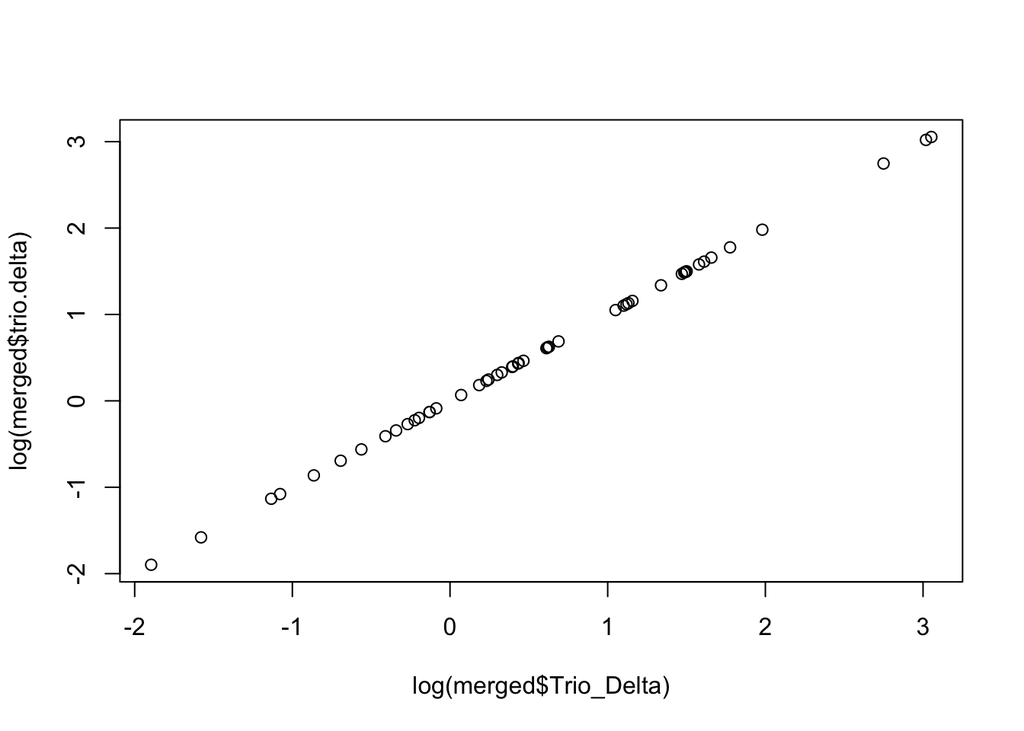

```r
dayan_results <- read_csv(file = "Sard_data/Genetic Pedigrees/Adults to Adults/Cervus/Output/2007_2010/dayan_out.csv")
sard_results <- read_csv(file = "Sard_data/Genetic Pedigrees/Adults to Adults/Cervus/Output/2007_2010/output.all.lod.csv")

#check if hav the same values, despite rounding differences
# same dims
# just going to plot a few values to check

colnames(dayan_results) <- gsub(" ", "_", colnames(dayan_results))
merged <- sard_results %>%
  left_join(dayan_results, by = c("off.id" = "Offspring_ID"))

plot(log(merged$`Trio_Delta`),log(merged$trio.delta))
```

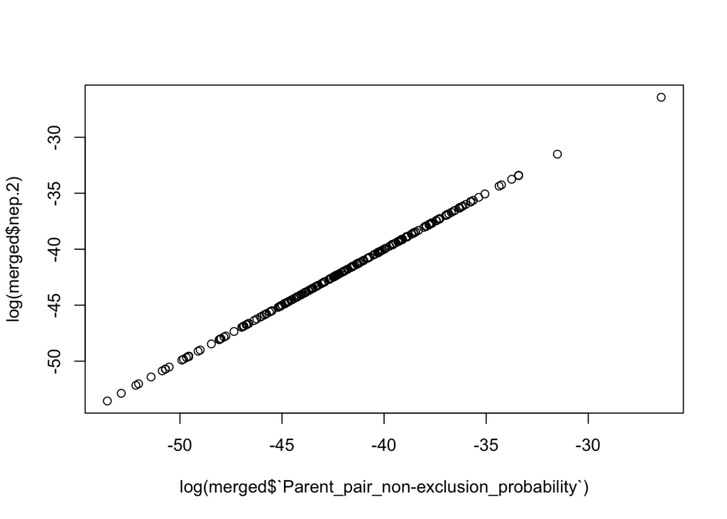

```r
plot(log(merged$`Parent_pair_non-exclusion_probability`),log(merged$nep.2))
```

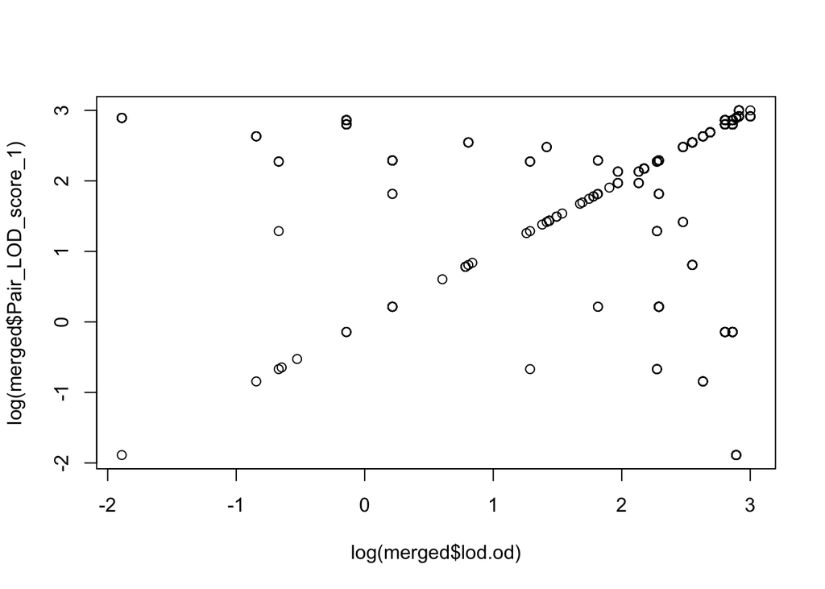

```r
plot(log(merged$lod.od), log(merged$Pair_LOD_score_1))
```

Hmmm, it appears that the trio-delta and the parent-pair non-exclusion probabilities are exactly the same, but the LOD has some values that vary between my run and Nick’s. No explanation for this yet. **note: resolved, please see section below for correct vervus run parameters**

#### 2012 Cohort

Here we attempt to recreate the CERVUS pedigree for the 2012 cohort (parents in 2007, 2008, 2009)

first create the datasets for CERVUS from the master genotype file

```r
# Genotype Files
# for each year-year pair collect parents and offspring, but note that we are building pedigree only for fish produced above the dam, so offspring year should only include fish with type = W
geno_2007_2012 <- b %>%
  filter(year == 2007 | (year == 2012 & type == "W")) %>%
  select(Sample.Name, OT201:Ot515_1)

geno_2008_2012 <- b %>%
  filter(year == 2008 | (year == 2012 & type == "W")) %>%
  select(Sample.Name, OT201:Ot515_1)

geno_2009_2012 <- b %>%
  filter(year == 2009 | (year == 2012 & type == "W")) %>%
  select(Sample.Name, OT201:Ot515_1)

# Dam file
# for sex, we use the sex.gt column, unless the value is RR or XX, then sex is assigned using pheno
b <- b %>%
  mutate(sex = case_when((sex.gt == "RR" | sex.gt=="XX") ~ sex.pheno, TRUE ~ sex.gt ))

dam_2007 <- b %>%
  filter(year == 2007 & sex == "F") %>%
  select(Sample.Name)

dam_2008 <- b %>%
  filter(year == 2008 & sex == "F") %>%
  select(Sample.Name)

dam_2009 <- b %>%
  filter(year == 2009 & sex == "F") %>%
  select(Sample.Name)

# Sire file
sire_2007 <- b %>%
  filter(year == 2007 & sex == "M") %>%
  select(Sample.Name)

sire_2008 <- b %>%
  filter(year == 2008 & sex == "M") %>%
  select(Sample.Name)

sire_2009 <- b %>%
  filter(year == 2009 & sex == "M") %>%
  select(Sample.Name)

# Offspring file
off_2012 <- b %>%
  filter((year == 2012 & type == "W")) %>%
  select(Sample.Name)

# write the files

write_tsv(geno_2007_2012, "recreating_2016_analysis/CERVUS_pedigree/CERVUS_input_files/geno_2007_2012.txt")
write_tsv(geno_2008_2012, "recreating_2016_analysis/CERVUS_pedigree/CERVUS_input_files/geno_2008_2012.txt")
write_tsv(geno_2009_2012, "recreating_2016_analysis/CERVUS_pedigree/CERVUS_input_files/geno_2009_2012.txt")

write_tsv(dam_2007, "recreating_2016_analysis/CERVUS_pedigree/CERVUS_input_files/dam_2007.txt")
write_tsv(dam_2008, "recreating_2016_analysis/CERVUS_pedigree/CERVUS_input_files/dam_2008.txt")
write_tsv(dam_2009, "recreating_2016_analysis/CERVUS_pedigree/CERVUS_input_files/dam_2009.txt")

write_tsv(sire_2007, "recreating_2016_analysis/CERVUS_pedigree/CERVUS_input_files/sire_2007.txt")
write_tsv(sire_2008, "recreating_2016_analysis/CERVUS_pedigree/CERVUS_input_files/sire_2008.txt")
write_tsv(sire_2009, "recreating_2016_analysis/CERVUS_pedigree/CERVUS_input_files/sire_2009.txt")
write_tsv(off_2012, "recreating_2016_analysis/CERVUS_pedigree/CERVUS_input_files/offspring_2012.txt")
```

Now run CERVUS on each year-year pair:

1. For each year-year pair estimate allele frequency file
2. Use alf file to gnerate sim file 10000 offspring use the number of actual candidate mothers and fathers from the dam/sire files use 70% sampled (from Sard 2016, note that we don’t know if the pedigree in the shared data is the one from the ms or from the technical report that used 98% sampled) genotyping error set to 2%
3. Use sim file to run parentage

**Combine Results into a Pedigree**

Now that we have all the assignments, we need to consolidate this info into a consensus pedigree for CERVUS. Parsing Nick’s scripts it seems like the following approach was taken:

0. Concatenate all years results into single dataset
1. For both parent assignments:
   1. remove all POPs (rows) with with either damPOP or sirePOP >1 mismatch
   2. keep parent offspring pairs with lowest mismatches (i.e. within a offspring choose either dam and sire indepedently based solely on number of mismatched )
   3. if multiple POPs have the same number of mismatches, use the LOD score (for each parent)
2. Single parent assignments:
   1. remove all POPs with >1 mismatch
   2. keep parent with lower mismatch
   3. if same number of mismatches, use LOD

A big thing to note here is that, whether intentionally or not, the pedigree is built primarily on the number of mismatches one parent at a time, (i.e. searches for the best dam by mismatches, then the best sire, not the best row in the output). This throws out nearly all the power that CERVUS has to make assignments over older exclusion based methods and (more importantly) it introduces the problem of creating impossible pedigrees (parents in different years), which are subsequently filtered, leading to unassigned offspring and biasing the central result of the study (CRR). We should check to see how big of an effect this has on assignment rate.

Info to keep for merging with COLONY results: pedigree, number of mismatches for each POP, parent years

```r
#get the raw results from CERVUS
POPs2007_2012 <- read_csv("recreating_2016_analysis/CERVUS_pedigree/CERVUS_outputs/2007_2012.csv")
POPs2008_2012 <- read_csv("recreating_2016_analysis/CERVUS_pedigree/CERVUS_outputs/2008_2012.csv")
POPs2009_2012 <- read_csv("recreating_2016_analysis/CERVUS_pedigree/CERVUS_outputs/2009_2012.csv")


#concatenate all 2012 offspring results
POPs2012 <- bind_rows(POPs2009_2012,POPs2007_2012, POPs2008_2012)

#let's do the filtering according to sard's protocol
#note that because the filtering worked on a single parent offspring pair, then combined dams and sire, it is easiest to do this twice (once for dams, once for sires) then combine
cer_ped_dam_2012 <- POPs2012 %>%
  filter(!(is.na(`Candidate mother ID`))) %>%#first lets get rid of all the blank rows
  filter(`Pair loci mismatching` <= 1 ) %>% #now get rid of all the POPs with >1 mismatch
  select(`Offspring ID`, `Candidate mother ID`, `Pair loci mismatching`, `Pair LOD score`) %>%
  group_by(`Offspring ID`) %>%
  filter(`Pair loci mismatching`==min(`Pair loci mismatching`)) %>%
  filter(`Pair LOD score`== max(`Pair LOD score`)) %>%  # now resolve any competitions (multiple parents per offsprings with same number of mismatches) by LOD
  ungroup() %>%
  distinct()

#now do the same for fathers
cer_ped_sire_2012 <- POPs2012 %>%
  filter(!(is.na(`Candidate father ID`))) %>%#first lets get rid of all the blank rows
  filter(`Pair loci mismatching_1` <= 1 ) %>% #now get rid of all the POPs with >1 mismatch
  select(`Offspring ID`, `Candidate father ID`, `Pair loci mismatching_1`, `Pair LOD score_1`) %>%
  group_by(`Offspring ID`) %>%
  filter(`Pair loci mismatching_1`==min(`Pair loci mismatching_1`)) %>%
  filter(`Pair LOD score_1`== max(`Pair LOD score_1`)) %>%  # now resolve any competitions (multiple parents per offsprings with same number of mismatches) by LOD
  ungroup() %>%
  distinct()

#join to create final pedigree
cer_ped_2012 <- POPs2012 %>%
  select(`Offspring ID`) %>%
  distinct() %>%
  left_join(cer_ped_dam_2012) %>%
  left_join(cer_ped_sire_2012)

#Next let's examine how many assignments are getting thrown out because of the across year issue
sum(substr(cer_ped_2012$`Candidate mother ID`,3,4) != substr(cer_ped_2012$`Candidate father ID`, 3,4), na.rm = TRUE)
```

```
## [1] 4
```

```r
#okay let's get rid of these year mismatches
cer_ped_2012 <- cer_ped_2012 %>%
  mutate(mom_year = str_sub(`Candidate mother ID`, 3,4)) %>%
  mutate(dad_year = str_sub(`Candidate father ID`, 3,4)) %>%
  mutate(`Candidate mother ID` = if_else(is.na(`Candidate father ID`),`Candidate mother ID`,if_else(mom_year!=dad_year, "UK", `Candidate mother ID`))) %>%
  mutate(`Candidate father ID` = if_else(is.na(`Candidate mother ID`),`Candidate father ID`,if_else(mom_year!=dad_year, "UK", `Candidate father ID`)))
```

Okay the combos across years only results in throwing out 4 (~1%) of assignments

**Compare to Nick’s Results**

First we compare the output files.

```r
sard_2012_pedigree <- read_tsv(file = "Sard_data/Genetic Pedigrees/Adults to Adults/Cervus_Colony_Comparison/Input/cervus.pedigree.2012.txt")

#check if hav the same values, despite rounding differences
#first convert "UK" to NA
sard_2012_pedigree <- sard_2012_pedigree %>%
#  mutate_at(c("mom.id", "dad.id"), list(~na_if(., "UK"))) %>%
  left_join(cer_ped_2012, by = c("off.id"="Offspring ID")) %>%
  rename_with(~ tolower(gsub(" ", "_", .x, fixed = TRUE))) %>%#get rid of spaces, getting annoying
  replace_na(list(candidate_mother_id ="UK", candidate_father_id="UK")) %>%
  mutate(mom_match=if_else(mom.id ==candidate_mother_id,TRUE,FALSE)) %>%
  mutate(dad_match=if_else(dad.id ==candidate_father_id, TRUE, FALSE))


#summarise differences
sum(sard_2012_pedigree$mom_match == TRUE & sard_2012_pedigree$dad_match == TRUE, na.rm = TRUE)
```

```
## [1] 491
```

There was a perfect match at 491 of 501 of the 2012 offspring.

Examining some of the differences  
MR12TH_066: Two dams with no mismatches, Sard chooses dam with LOWER LOD score  
MR12TH_343: year mismatch in dayan results, so its hard to figure out  
MR12TH_002: two sires with 1 mismatch, Sard chose sire with lower LOD  
MR12TH_124: year mismatch in dayan results, so its hard to figure out  
MR12TH_302: same thing, sard chose lower LOD score

Double checked the stated methods, It appears that the differences in results stem from a small error in some of Sard’s code. When two candidate parents have the same number of mismatches, Sard’s results sometimes choose the less likely parent (lower LOD score). This could explain the discrepancies where my results have been tossed because parents are in different years as well. The offending piece of code settles ties using the LOD for the parent offspring **trio** instead of the parent in question’s LOD score, despite the fact the the code chooses each parent separately. However, because the can be many possible trio with the same small set of parents (i.e. one ofsspring, two dams with equal mismatches and two sires can produce 4 parent-offpsring trios) a higher LOD for the trio is sometimes observed despite a lower LOD for an individual parent.

If we choose to fix this, we should either make assignments at the trio level, or simply leave the code as is above (use single parent LOD score for single parent assignment)

### Colony

Colony run details were parsed from a project information file shared by Sard.

**Run Parameters**

> Output file path & name : ‘C:2015 returns run22015 returns run2’ Number of loci : 11 Number of offspring in the sample : 263 Outbreeding (0) or inbreeding (1) model : 0 Number of male candidates : 2171 Number of female candidates : 1621 Number of known paternal sibships : 0 Number of known maternal sibships : 0 Number of offspring with excluded fathers : 0 Number of offspring with excluded mothers : 0 Male mating system : Polygamy Female mating system : Polygamy Number of threads : 1 Number of Excluded Paternal Sibships : 0 Number of Excluded Maternal Sibships : 0 Dioecious (2) or monoecious (1) : 2 Seed for random number generator : 159 Allele frequency : No updating by accounting for the inferred relationship Species : Diploid Sibship scaling : Yes Sibship size prior : Yes paternal & maternal sibship sizes : 1 1 Known population allele frequency : No Number of run : 1 Length of run : Medium Monitor intermiediate results by : Every 1 second Prob. a dad is included in the male candidates : .70 Prob. a mum is included in the female candidates : .70 Project data input produced : 04/01/2016 NOTE to the Project:

Should also note that from the input files provided by Sard, it is clear that (unlike the approach used with CERVUS) COLONY was run with all potential parents for a given offspring cohort in a single run, improving power to identify correct trios, but introducing the possibility of impossible trio (different years), colony provides a pairwise black list option (exclude impossible parent pairs), so we could run with greater power if we wanted to and avoid tossing assignments because of year-year mismatches

```r
require(rcolony)
rcolony::build.colony.input()
```

#### 2012 Cohort

Here we attempt to use a r based wrapper for colony with some convenient functions (plus the developer is locked out of his office due to COVID and can’t update the expired mac version of the software)

We’ll use the input file wizard to generate a .DAT file (input for colony), then run this on the server. Problem is that the versions vary… used this wizard then made a couple changes to the .DAT file:

1. copied first parameter section from the example file included with the software, then set to params from Sards project file
2. number of known parent offspring dyads lines (first two lines after all the genotype info) need to have two 0s, not one

check the 2012 cohort .DAT file and use as template for other runs

```r
#pedigree file is multisapced delimited,

col_ped_2012_dayan <- read_table("recreating_2016_analysis/COLONY_pedigree/2012_output/2012_cohort.BestConfig")
col_ped_2012_sard <- read_tsv("Sard_data/Genetic Pedigrees/Adults to Adults/Cervus_Colony_Comparison/Input/colony.pedigree.2012.txt")

merged_col_ped_2012 <- col_ped_2012_dayan %>%
  rename(father_dayan = FatherID, mother_dayan = MotherID) %>%
  select(OffspringID, father_dayan, mother_dayan) %>%
  left_join(col_ped_2012_sard, by = c("OffspringID" = "OffspringID")) %>%
  mutate_all(funs(str_replace(., "Dad_.+|Mom_.+", "UK"))) %>%
  mutate_all(funs(str_replace(., "\\#\\d+|\\*\\d+", "UK"))) %>%
  mutate(dad_match = father_dayan==FatherID) %>%
  mutate(mom_match = mother_dayan==MotherID)

sum(merged_col_ped_2012$mom_match == TRUE & merged_col_ped_2012$dad_match == TRUE, na.rm = TRUE)
```

[output not shown]

Findings: sard used different colony settings across different colony runs, my run followed the parameters used for sards 2015 run, which I assumed would be the same, ran again with sards 2012 settings (changed sibship settings, run length, etc )

Another issue is thatcolony user guide is STRONGLY suggests converging results from replicates runs with different starting seeds, because it realizes on a MCMC-like approach for estimating likelihoods.

```r
#pedigree file is multisapced delimited,

col_ped_2012_dayan <- read_table("recreating_2016_analysis/COLONY_pedigree/2012_output/2012_cohort.BestConfig")
col_ped_2012_sard <- read_tsv("Sard_data/Genetic Pedigrees/Adults to Adults/Cervus_Colony_Comparison/Input/colony.pedigree.2012.txt")

merged_col_ped_2012 <- col_ped_2012_dayan %>%
  rename(father_dayan = FatherID, mother_dayan = MotherID) %>%
  select(OffspringID, father_dayan, mother_dayan) %>%
  left_join(col_ped_2012_sard, by = c("OffspringID" = "OffspringID")) %>%
  mutate_all(funs(str_replace(., "Dad_.+|Mom_.+", "UK"))) %>%
  mutate_all(funs(str_replace(., "\\#\\d+|\\*\\d+", "UK"))) %>%
  mutate(dad_match = father_dayan==FatherID) %>%
  mutate(mom_match = mother_dayan==MotherID)

sum(merged_col_ped_2012$mom_match == TRUE & merged_col_ped_2012$dad_match == TRUE, na.rm = TRUE)
```

```
## [1] 418
```

```r
#what about the file sdirectly out of colony?
sars2012col <- read_table("Sard_data/Genetic Pedigrees/Adults to Adults/COLONY/Pedigrees/Mck_2012_returns/Mck_2012_returns.BestConfig")
col_ped_2012_dayan <- read_table("recreating_2016_analysis/COLONY_pedigree/2012_output/2012_cohort.BestConfig")


merged_col_ped_2012_2 <- col_ped_2012_dayan %>%
  rename(father_dayan = FatherID, mother_dayan = MotherID) %>%
  select(OffspringID, father_dayan, mother_dayan) %>%
  left_join(sars2012col, by = c("OffspringID" = "OffspringID")) %>%
  mutate_all(funs(str_replace(., "\\#\\d+|\\*\\d+", "UK"))) %>%
  mutate(dad_match = father_dayan==FatherID) %>%
  mutate(mom_match = mother_dayan==MotherID)


sum(merged_col_ped_2012_2$mom_match == TRUE & merged_col_ped_2012_2$dad_match == TRUE, na.rm = TRUE)
```

```
## [1] 418
```

```r
#results are the same as the pedigree reportd elesewhere in the SArd database
```

Ok exact same settings as the final Sard run for this year, only 2 better assignment concordance. Lets see how much this is due to cross run variance (run again on the exact same data with same setting and see how much the resutls vary)

```r
col_ped_2012_dayan_2 <- read_table("recreating_2016_analysis/COLONY_pedigree/2012_output/2012_2/2012_cohort.BestConfig")

all_equal(col_ped_2012_dayan, col_ped_2012_dayan_2)

col_ped_2012_dayan_3 <- read_table("recreating_2016_analysis/COLONY_pedigree/2012_output/2012_cohort_3.BestConfig")

all_equal(col_ped_2012_dayan, col_ped_2012_dayan_3)
```

[output not shown]

No variance at all in colony results across three separate runs, differences are unlikely due to different mcmc seeds.

### Composite Pedigree

The final pedigrees used in the analysis are composite results from the COLONY and CERVUS runs

From Sard 2016 supplement:  
>For observed differences between assignment programs, we chose the assignment used in the final genetic pedigree based on several criteria. In brief, assignments with the lowest number of mismatches between parent and offspring took precedence. In addition, offspring that assigned to both parents in a given year took precedence over assignments to a single parent in a different year, based on non-exclusionary power calculations (Table S3). If the number of mismatches were the same the COLONY based assignment took precedence (see Harrison et al., 2013). Composite genetic pedigrees following these criteria were used for all subsequent analyses.

From the “pedigree.compar” scripts, it appears the this is the algo used to determine the composite pedigree:  
(a) pull the pedigrees from CERVUS and colony  
(b) add the number of mismatches and parent years to the pedigrees (colony pedigree mismatches from cervus outputs) , then filter based on mismatched (note this is not done for the raw colony pedigree only before merging) (c) join pedigrees  
(d) check for concordance between results  
(e) for each offspring in pedigree:  
- keep if same assignment  
- if different assignment (in order):  
- same year of both parents (toss the pedigree with year mismatch)  
- kept assignment from pedigree a if pedigree b does not make an assignment (either single or both parents)  
- both parents have assignment in both CERVUS and COLONY pedigrees, but there is a disagreement: go with COLONY  
- single parent match, but diasagree: go with lower mismatch number (if same mm go with COLONY)

*note* this is slightly different from what is written in the methods sections of the various reports and ms. In the methods sections it says when there is a disagreement between assignments (other than for non-assignments) then the decision is based on the number of mismatches. However, in the case where both parents disagree, the algorithm above defaults to COLONY so long as both pedigrees made full trio assignments, even if there were more mismatches.

```r
# joint 2012 pedigree

#prep the cervus pedigree (change NA to "UK" for non-match), rename cols for easier merging later
cer_ped_2012 <- cer_ped_2012 %>%
  replace_na(list(`Candidate mother ID` = "UK", `Candidate father ID` = "UK")) %>%
  rename(cervus_mom = `Candidate mother ID`, cervus_dad = `Candidate father ID`, mom_mm = `Pair loci mismatching`, dad_mm = `Pair loci mismatching_1`, mom_lod = `Pair LOD score`, dad_lod = `Pair LOD score_1`)

#prep colony pedigree (add in mismatches from raw cervus outputs, add in parent year)
#first create a dataframe of mismatch info for maternal and paternal POPs
mom_mismatches <- POPs2012 %>%
  select(`Offspring ID`, `Candidate mother ID`, `Pair loci mismatching`) %>%
  drop_na() %>%
  distinct() %>%
  rename(mom_mm = `Pair loci mismatching`)

dad_mismatches <- POPs2012 %>%
  select(`Offspring ID`, `Candidate father ID`, `Pair loci mismatching_1`) %>%
  drop_na() %>%
  distinct() %>%
  rename(dad_mm = `Pair loci mismatching_1`)

#now merge these with the colony pedigree
col_ped_2012_dayan <-  col_ped_2012_dayan %>%
  left_join(mom_mismatches, by = c(OffspringID = "Offspring ID", MotherID = "Candidate mother ID")) %>%
    left_join(dad_mismatches, by = c(OffspringID = "Offspring ID", FatherID = "Candidate father ID"))

#rename non-assignments to "UK" and prep columns for merge

col_ped_2012_dayan <- col_ped_2012_dayan %>%
  mutate_all(funs(str_replace(., "\\#\\d+|\\*\\d+", "UK"))) %>%
  rename(colony_dad = FatherID, colony_mom = MotherID, mom_mm_colony = mom_mm, dad_mm_colony = dad_mm)

col_ped_2012_dayan <- col_ped_2012_dayan %>%
  mutate(mom_year_col = str_sub(colony_mom, 3,4)) %>%
  mutate(dad_year_col = str_sub(colony_dad, 3,4))

#set mismatches >1 to UK
col_ped_2012_dayan <- col_ped_2012_dayan %>%
  mutate(colony_mom = if_else(mom_mm_colony >1 , "UK", colony_mom)) %>%
  mutate(colony_dad = if_else(dad_mm_colony >1 , "UK", colony_dad))


# merge
merged2012_ped <- col_ped_2012_dayan %>%
  left_join(cer_ped_2012, by = c("OffspringID" = "Offspring ID"))

#create consensus according to Sard algorithm
consensus_2012_ped <- merged2012_ped %>%
  mutate_at(c("cervus_mom", "cervus_dad", "colony_dad", "colony_mom"), list(~na_if(., "UK"))) %>%#first convert all the UKs to NAs
  mutate(final_mom = if_else((cervus_mom == colony_mom) & (cervus_dad == colony_dad), colony_mom, NA_character_)) %>% # first if there is a perfect match for both parents, write out both mom and dad, if not write out an NA
  mutate(final_dad = if_else((cervus_mom == colony_mom) & (cervus_dad == colony_dad), colony_dad, NA_character_)) %>%
  mutate(colony_mom = if_else(mom_year_col == dad_year_col, colony_mom, NA_character_)) %>%
  mutate(colony_dad = if_else(mom_year_col == dad_year_col, colony_dad, NA_character_)) %>% #if both parents are assigned in both methods, but there is a disagreement, first choose based on year year mismatches, the easiest way to accomplish this is to just toss parents with year mismatches and wait for the next step which assigns parentage if one method has a POP, but the other does not, this was already done for the cervus pedigrees so we only have to do it once
  mutate(final_mom = if_else(!(is.na(final_mom)), final_mom, if_else((is.na(colony_mom)) & !(is.na(cervus_mom)), cervus_mom, NA_character_))) %>%
  mutate(final_mom = if_else(!(is.na(final_mom)), final_mom, if_else((is.na(cervus_mom)) & !(is.na(colony_mom)), colony_mom, NA_character_))) %>%
    mutate(final_dad = if_else(!(is.na(final_dad)), final_dad, if_else((is.na(colony_dad)) & !(is.na(cervus_dad)), cervus_dad, NA_character_))) %>%
  mutate(final_dad = if_else(!(is.na(final_dad)), final_dad, if_else((is.na(cervus_dad)) & !(is.na(colony_dad)), colony_dad, NA_character_))) %>%# if one method makes assignment but the other is unknown go with whatever has an assignment
  mutate(final_dad = if_else(!(is.na(final_dad)), final_dad, if_else((!(is.na(colony_dad)) & !(is.na(colony_mom)) & !(is.na(cervus_dad)) & !(is.na(cervus_mom))) & (colony_dad != cervus_dad), colony_dad, NA_character_))) %>%
    mutate(final_mom = if_else(!(is.na(final_mom)), final_mom, if_else((!(is.na(colony_dad)) & !(is.na(colony_mom)) & !(is.na(cervus_dad)) & !(is.na(cervus_mom))) & (colony_mom != cervus_mom), colony_mom, NA_character_))) %>% #both parents assigned in both methods, but disagree, default to colony, also need to assign the opposite parent (where there is agreement)next 2 lines
   mutate(final_mom = if_else(!(is.na(final_mom)), final_mom, if_else(!(is.na(colony_dad)) & !(is.na(colony_mom)) & !(is.na(cervus_dad)) & !(is.na(cervus_mom)), colony_mom, NA_character_))) %>%
    mutate(final_dad = if_else(!(is.na(final_dad)), final_dad, if_else(!(is.na(colony_dad)) & !(is.na(colony_mom)) & !(is.na(cervus_dad)) & !(is.na(cervus_mom)), colony_dad, NA_character_))) %>%
 mutate(final_dad = if_else(!(is.na(final_dad)), final_dad, if_else((!(is.na(colony_dad)) & (is.na(colony_mom)) & !(is.na(cervus_dad)) & (is.na(cervus_mom))) & (colony_dad !=cervus_dad), if_else((dad_mm_colony >= dad_mm), colony_dad, NA_character_), NA_character_))) %>%
  mutate(final_dad = if_else(!(is.na(final_dad)), final_dad, if_else((!(is.na(colony_dad)) & (is.na(colony_mom)) & !(is.na(cervus_dad)) & (is.na(cervus_mom))) & (colony_dad !=cervus_dad), if_else((dad_mm > dad_mm_colony), cervus_dad, NA_character_), NA_character_))) %>%
   mutate(final_mom = if_else(!(is.na(final_mom)), final_mom, if_else((!(is.na(colony_mom)) & (is.na(colony_dad)) & !(is.na(cervus_mom)) & (is.na(cervus_dad))) & (colony_mom !=cervus_mom), if_else((mom_mm_colony >= mom_mm), colony_mom, NA_character_), NA_character_))) %>%
  mutate(final_mom = if_else(!(is.na(final_mom)), final_mom, if_else((!(is.na(colony_mom)) & (is.na(colony_dad)) & !(is.na(cervus_mom)) & (is.na(cervus_dad))) & (colony_mom !=cervus_mom), if_else((dad_mm > dad_mm_colony), cervus_mom, NA_character_), NA_character_))) %>%#single parent match, but diasagree: go with lower mismatch number (if same mm go with COLONY)
  mutate(final_dad = if_else(!(is.na(final_dad)), final_dad, if_else((!(is.na(colony_dad)) & !(is.na(cervus_dad))) & (colony_dad == cervus_dad),colony_dad,NA_character_))) %>%
  mutate(final_mom = if_else(!(is.na(final_mom)), final_mom, if_else((!(is.na(colony_mom)) & !(is.na(cervus_mom))) & (colony_mom == cervus_mom),colony_mom,NA_character_)))
#single parent match and agree

#clean up this dataset to match sard final peds
sard_final_2012 <- read_tsv("Sard_data/Genetic Pedigrees/Adults to Adults/Cervus_Colony_Comparison/Output/2012.combined.pedigree.txt")

final2012_ped <- consensus_2012_ped %>%
  select(OffspringID, final_mom, final_dad) %>%
  left_join(sard_final_2012, by = c("OffspringID" = "offspring")) %>%
  replace_na(list(final_mom = "UK", final_dad = "UK"))

#check if this dataset is correct
final2012_ped$mom_match <- (final2012_ped$final_mom == final2012_ped$mom)
final2012_ped$dad_match <- (final2012_ped$final_dad == final2012_ped$dad)
final2012_ped$bothmatch <- ((final2012_ped$mom_match == T ) & (final2012_ped$dad_match == T))

sum(final2012_ped$bothmatch, na.rm = T)
```

```
## [1] 488
```

Our pedigrees our share 488 out of 501 assignments exactly, 97.5%

Below we examine each of the disagreements and attempt to figure out what went wrong.

MR12TH_032: I assigned MR07_073 as father with no mother, but Sard made no assignment, possible reason: each (parent and offspring) missing one locus, but different, so only 9 loci compared… should investigate this further to see if Sard scripts throw these out, but I think this is an error in my code (I failed to filter the same way)

MR12TH_150: I assigned MR07_124 as father, no assignment in Sard. Sard’s father assignment had 2 mm and was thrown out, yet, MR07_124 has 1 mm. again only genotyped at 9 sites.

MR12TH_157: I made no final assignments, despite identifying MR07_163 as a father in colony, Sard assigned MR07_163 as father. It appears that the cervus run (where we get mismatches info from) did not have a row for this POP (used the only show positive LOD score filter in cervus maybe)

MR12TH_215: I assigned MR07_173 as mom (1mm), no assignments for Sard. Sard finds same mom as colony and cervus result, genotyped at 10 loci. Filtered out because 2mm despite earlier result showing 1mm.

MR12TH_238: Same error as 215, Sard throws out MR07_173 as dam because data used for filtering shows 2mm, despite only one mismatch in their cervus results, seems like error in script merging results before building the consensus pedigree

MR12TH_252: agree on father assignment, different mother assignment. MR07_064 (dayan) has zero mismatches in both Dayan and Sard cervus results, and is the best mother under Dayan colony results, but MR07_271 is best mother under Sards colony results, despite the fact that there is 1mm.

MR12TH_268: appears to be full sib or duplicate to _252, same exact results as above. This difference is because my run did not filter out potential fallbacks (dups), will fix in final runs.

MR12TH_451: Sard assigns MR09A_0200 as mom, Dayan makes no assignment. Dayan threw out cervus assignments because they were across years, assigns MR07_790 in colony results (1mm), Sard also assigns MR07_790 as mother using cervus, but MR09A_0200 as colony result (also with 1mm). difference here is that our colony runs favored different parents with the same number of mismatches across runs.

MR12TH_476: Dayan, no final assignments, Sard: MR07_224 as father. Dayan assigned MR07_224 as father in colony, but was tossed because no mm info (need to keep all rows of cervus output to collect mm info)

MR12TH_496: Dayan final dad: MR07_741, Sard final dad MR07_224. Dayan: cervus _741 (1mm), colony _224 (no mm info). Sard cervus _741 (1mm), but 224 for colony, no idea where Sard got the mm info from because it’s also missing from their cervus output files. labeled as 1mm. we’ve seen before that the mm info used for the final consensus pedigree has errors in it, perhaps this is one of them. Need to go in an carefully check out the for loop that writes these data out.

MR12TH_515: Sard final mo MR08_779, no final assignments for Dayan. Dayan cervus finds no parent, MR08_447 for mom in colony (but with no mm data), Sard find MR08_779 as mom in colony, but nothing in cervus (so where the mm data come from?)

### Issues

We arrived at 97.5% concordance between our final pedigree and Nick Sard’s pedigree for the 2012 cohort. The 2.5% discordance can mostly be resolved by fixing a few small errors mostly in my code, these are outlined above.

However, there are larger unresolved issues (which I mostly left in my code in attempting to perfectly recreate Sard’s results), that need to be addressed.

list of issues: (2) Cervus is run year to year, then all results are concatenated and considered collectively. Parents are then selected one at a time on the basis of number of mismatches. This creates two major issues. First, it renders all statistics other than the number of mismatches meaningless (likelihoods can not be compared across different data). Second, in combination with assigning parents one by one, it leads to a scenario where impossible parentage combinations are possible (different years). This leads to parentage being tossed out even when a reasonable/high scoring parent offspring trio was available. Third, colony is not run in the same fashion, but instead considered all possible parents simultaneously, including impossible combinations.  
(3) Choosing among good POPs in Cervus. The algorithm for choosing which of several likely POPs in cervus relies first on number of mismatches, disregarding the more informative LOD score unless there is a tie. While there should be good agreement here, htere are cases when they do not agree. Additionally there is also an error where ties are broken using the wrong statistics (parent offspring trio LOD, whereas parents are assigned as parent offspring pairs).  
(4) Colony run differences: colony uses something akin to a mcmc to estimate parentage probablilities. Sard’s pedigrees are based on a single run. My colony runs (only did 3) produce the same results, suggesting we have enough info to converge on similar answers, but there is still an unresolved issue here - our run parameters are exactly the same, yet produce slightly different results for a small number of offspring. Colony developer does not dsitribute versioned copies of colony, so it could be due to an update to the software as well.  
(5) Disagreement between methods in ms and USACE/ODFW reports and my interpretation of the scripts. There are several details in the stated methods that do not align with (from what I can tell) are the actual methods used to assign parentage. (a) The first is covered in (3) above. The methods imply LOD is being used when it is not except to decide ties. (b) A second, more important issue is that the ms states that the composite pedigree defaults to the colony results only when there is a tie in the mumber of mismatches, however the code gives the tie to colony whenever both parents were assigned by both methods, regardless of the number mismatches. (c) The ms states that offspring that assigned to both parents in a given year took precedence over assignments to a single parent in a different year. This seems absent from the code (maybe it never happened in the data).  
(6) Sard’s dataset that is used to make the consensus pedigree contains some rows with errors. i.e. The number of mismatches between some parent-offspring pairs does not agree with their previous results or Dayan’s results using the same raw data. This leads to some parents assigned despite better alternatives available. It is unclear where these numbers come from (can’t find the error that produces them yet). Seems like only a tiny number of rows with this issue though.  
(8) Colony is run with all possible parent combos leading to impossible trios (different parent years) that are subsequently filtered out, even though good parents may still be available, biases CRR downwards.

These issues can be divided into two categories: (i) small differences in code sometimes due to errors that produce minor differences between Dayan and Sard’s results and can be reconciled one way or another, (ii) fundamental issues with the approach incorporated into both’s code that either (a) potentially lead to spurious results or (b) significantly differ from the methods in the manuscript.

While (i) can mostly be resolved if the goal is simply to perfectly recreate previous results, (ii) presents a more serious problem because they bias the final conclusions of the manuscript. For example, consider issue (2) from above (cervus is run year to year, then concatenated). This results in several offspring with clear parents in the dataset, but no assignment in the pedigree used to estimate the cohort replacement rate or fitness metrics. This biases fitness and CRR estimates downward.

Little notes:  
- Using mismatches: similar to (2) above, the number of mismatches is given precedence over all other results. While there may be a justification for this approach there is one area that causes a major problem. The number of mismatches for a parent offspring pair is calculated in cervus, but then used to filter colony results. Given that cervus does not output mm results for all parent offspring pairs by default, some POPs assigned in colony by Dayan are missing info and tossed out. This produces a small number of the disagreements in the final pedigrees, but can be fixed in later runs.